# Example Project: CEO Salaries

## Assignment

There can be many different reasons behind fitting a model to such a data set, for example:

- assessing the effect of a specific variable, e.g. education, on CEO salaries,
- interpretable prediction, e.g. for salary negotiations purposes, or
- determining whether is a specific observation unusual, e.g. for a litigation concerning compensations.

Let’s say we are going with the first option, and we are interested in the effect of education.

**Notes**:

- The section above is part of both this initial analysis just for convenience, to have the assignment at the same place as the solution.
- The solution provided is not perfect by any means.
  - for example, it seems that `pcntown` and `prof` are zero for most CEOs and we should consider adding some indicators
  - the cross-validation we do at the end of the document (in a separate script) is computationally wasteful - we could do leave-one-out by only fitting the model once
- I read data many time throughout the document, which is **bad**. I should read it once and somewhat keep track to what I do with my data. Anyway, for this purpose, I wrote the function `read_data()`, taking into account that the default working directory of the this Rmarkdown (when knitted) is different from the of our R project (“AppStat”).
  - it would be better to call log-transformed variable `xxx` e.g. by `log_xxx` and keeping both in the data instead of replacing `xxx` with its log-transformation - using this, I would only need to read data once and the ggplots of the variables would contain more info

## Reading and Exploring data

```r
read_data <- function(Rmarkdown=T){
  if(Rmarkdown){
    Data <- read.csv("../Project-0/CEO_compensations.csv")
  }else{
    Data <- read.csv("./Project-0/CEO_compensations.csv")
  }
  return(Data)
}
Data <- read_data()
# Data <- read_data(F)
str(Data)
```

```
## 'data.frame':    100 obs. of  12 variables:
##  $ COMP   : int  1948 809 721 2027 2094 570 1833 1126 1300 668 ...
##  $ AGE    : int  55 59 53 62 63 60 63 64 50 62 ...
##  $ EDUCATN: int  1 1 2 2 1 1 2 1 2 2 ...
##  $ BACKGRD: int  1 2 1 2 3 4 3 3 5 3 ...
##  $ TENURE : int  23 38 26 25 41 3 36 28 2 35 ...
##  $ EXPER  : num  23 0.5 0.5 5 8 3 7 14 2 20 ...
##  $ SALES  : int  1227 19196 839 8379 10818 804 17037 2545 1412 3950 ...
##  $ VAL    : num  7.6 0.4 1.5 3.4 5.9 ...
##  $ PCNTOWN: num  0.55 0.01 0.1 0.04 0.04 ...
##  $ PROF   : int  145 505 -60 806 1166 49 709 63 -35 -80 ...
##  $ COMPANY: chr  "AdvM" "aetna" "aller" "amer" ...
##  $ BIRTH  : chr  "chi" "chi" "sanf" "vertx" ...
```

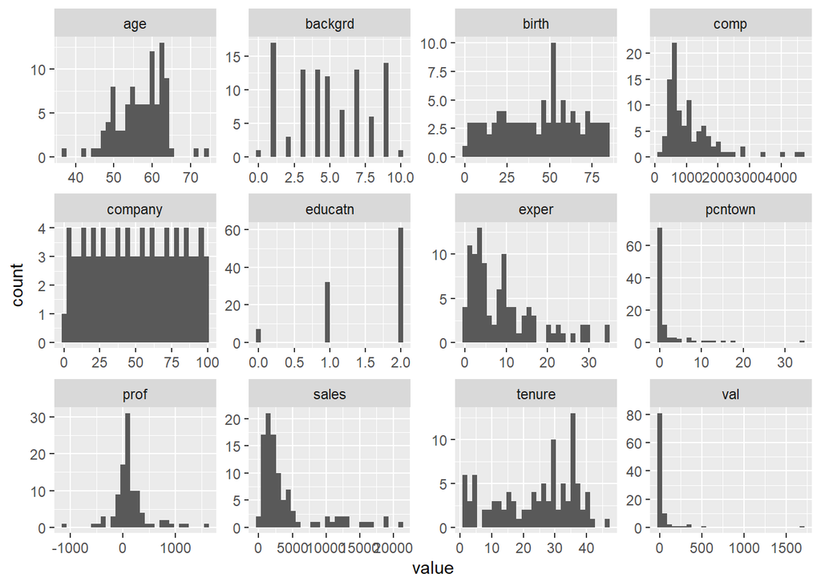

```r
names(Data) <- tolower(names(Data))

Data %>% mutate(company=as.numeric(as.factor(company)), birth=as.numeric(as.factor(birth))) %>%
  pivot_longer(everything()) %>%
  ggplot(aes(value)) + facet_wrap(~ name, scales = "free") + geom_histogram()
```

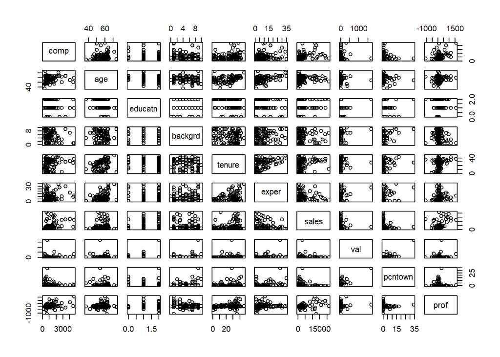

```r
Data %>% select(-company,-birth) %>% pairs()
```

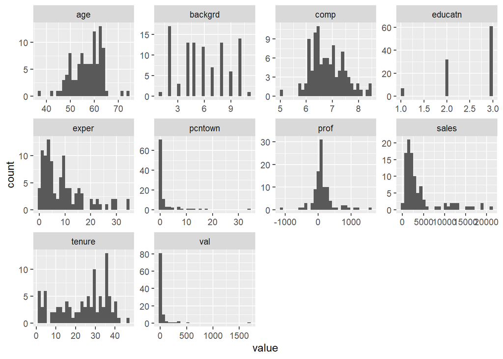

```r
Data <- Data %>% mutate(backgrd=as.factor(backgrd), educatn=as.factor(educatn), comp=log(comp)) %>%
  select(-birth,-company)

Data %>% mutate(backgrd=as.numeric(backgrd), educatn=as.numeric(educatn)) %>% pivot_longer(everything()) %>%
  ggplot(aes(value)) + facet_wrap(~ name, scales = "free") + geom_histogram()
```

Education level and background should probably be factors, and we are discarding `birth` and `company` since those are mostly unique and hence we do not have enough data to take them into account in modeling. For the response, we take logarithm for obvious reasons.

## First Model

```r
m1 <- lm(comp~., data=Data)
anova(m1)
```

```
## Analysis of Variance Table
##
## Response: comp
##           Df  Sum Sq Mean Sq F value    Pr(>F)
## age        1  2.2198  2.2198  7.3224 0.0083206 **
## educatn    2  2.2332  1.1166  3.6833 0.0294968 *
## backgrd   10  3.0394  0.3039  1.0026 0.4486158
## tenure     1  0.1163  0.1163  0.3836 0.5374559
## exper      1  0.2878  0.2878  0.9494 0.3328213
## sales      1  4.5016  4.5016 14.8493 0.0002339 ***
## val        1  0.1751  0.1751  0.5777 0.4494556
## pcntown    1  2.2236  2.2236  7.3348 0.0082684 **
## prof       1  1.0254  1.0254  3.3825 0.0696040 .
## Residuals 80 24.2522  0.3032
## ---
## Signif. codes:  0 '***' 0.001 '**' 0.01 '*' 0.05 '.' 0.1 ' ' 1
```

```r
m0 <- lm(comp~.-backgrd-tenure-exper-val, data=Data)
anova(m0,m1)
```

```
## Analysis of Variance Table
##
## Model 1: comp ~ (age + educatn + backgrd + tenure + exper + sales + val +
##     pcntown + prof) - backgrd - tenure - exper - val
## Model 2: comp ~ age + educatn + backgrd + tenure + exper + sales + val +
##     pcntown + prof
##   Res.Df    RSS Df Sum of Sq      F Pr(>F)
## 1     93 27.938
## 2     80 24.252 13    3.6857 0.9352 0.5214
```

```r
m1 <- m0
anova(m1)
```

```
## Analysis of Variance Table
##
## Response: comp
##           Df  Sum Sq Mean Sq F value    Pr(>F)
## age        1  2.2198  2.2198  7.3893  0.007827 **
## educatn    2  2.2332  1.1166  3.7170  0.027991 *
## sales      1  5.0973  5.0973 16.9679 8.236e-05 ***
## pcntown    1  1.1013  1.1013  3.6661  0.058604 .
## prof       1  1.4849  1.4849  4.9428  0.028622 *
## Residuals 93 27.9379  0.3004
## ---
## Signif. codes:  0 '***' 0.001 '**' 0.01 '*' 0.05 '.' 0.1 ' ' 1
```

Did we miss anything:

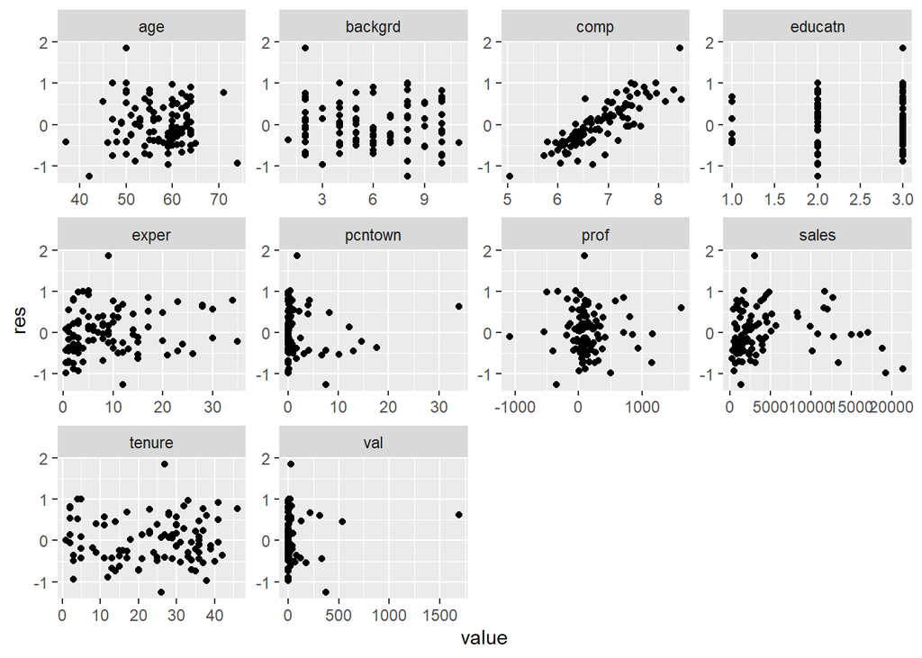

```r
resData <- Data
resData$res <- resid(m1)
resData %>% mutate(backgrd=as.numeric(backgrd), educatn=as.numeric(educatn)) %>% pivot_longer(colnames(resData)[colnames(resData) != "res"]) %>%
  ggplot(aes(y=res,x=value)) + facet_wrap(~ name, scales = "free") + geom_point()
```

There is some residual dependency on `sales`, which should have been taken on a log-scale in the first place. Let’s do the same again but with the log:

```r
Data <- Data %>% mutate(sales=log(sales))
m1 <- lm(comp~., data=Data)
anova(m1)
```

```
## Analysis of Variance Table
##
## Response: comp
##           Df  Sum Sq Mean Sq F value    Pr(>F)
## age        1  2.2198  2.2198  8.1508   0.00548 **
## educatn    2  2.2332  1.1166  4.1000   0.02018 *
## backgrd   10  3.0394  0.3039  1.1160   0.36081
## tenure     1  0.1163  0.1163  0.4270   0.51535
## exper      1  0.2878  0.2878  1.0568   0.30706
## sales      1  7.5316  7.5316 27.6547 1.181e-06 ***
## val        1  0.4346  0.4346  1.5957   0.21018
## pcntown    1  1.3266  1.3266  4.8709   0.03018 *
## prof       1  1.0978  1.0978  4.0308   0.04805 *
## Residuals 80 21.7874  0.2723
## ---
## Signif. codes:  0 '***' 0.001 '**' 0.01 '*' 0.05 '.' 0.1 ' ' 1
```

```r
m0 <- lm(comp~.-backgrd-tenure-exper-val, data=Data)
anova(m0,m1)
```

```
## Analysis of Variance Table
##
## Model 1: comp ~ (age + educatn + backgrd + tenure + exper + sales + val +
##     pcntown + prof) - backgrd - tenure - exper - val
## Model 2: comp ~ age + educatn + backgrd + tenure + exper + sales + val +
##     pcntown + prof
##   Res.Df    RSS Df Sum of Sq      F Pr(>F)
## 1     93 25.333
## 2     80 21.787 13    3.5452 1.0013 0.4581
```

```r
m1 <- m0
anova(m1)
```

```
## Analysis of Variance Table
##
## Response: comp
##           Df  Sum Sq Mean Sq F value    Pr(>F)
## age        1  2.2198  2.2198  8.1493  0.005311 **
## educatn    2  2.2332  1.1166  4.0992  0.019673 *
## sales      1  7.9198  7.9198 29.0747 5.259e-07 ***
## pcntown    1  1.1022  1.1022  4.0462  0.047165 *
## prof       1  1.2668  1.2668  4.6506  0.033622 *
## Residuals 93 25.3326  0.2724
## ---
## Signif. codes:  0 '***' 0.001 '**' 0.01 '*' 0.05 '.' 0.1 ' ' 1
```

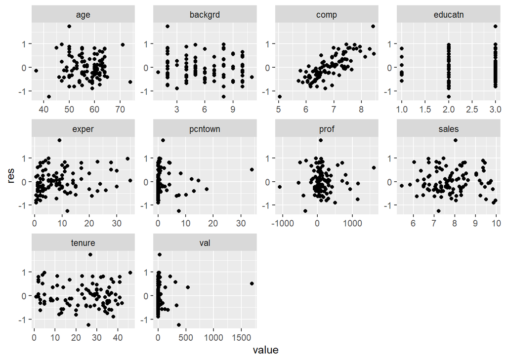

```r
resData <- Data
resData$res <- resid(m1)
resData %>% mutate(backgrd=as.numeric(backgrd), educatn=as.numeric(educatn)) %>% pivot_longer(-res) %>%
  ggplot(aes(y=res,x=value)) + facet_wrap(~ name, scales = "free") + geom_point()
```

Looks like a decent model, check residuals:

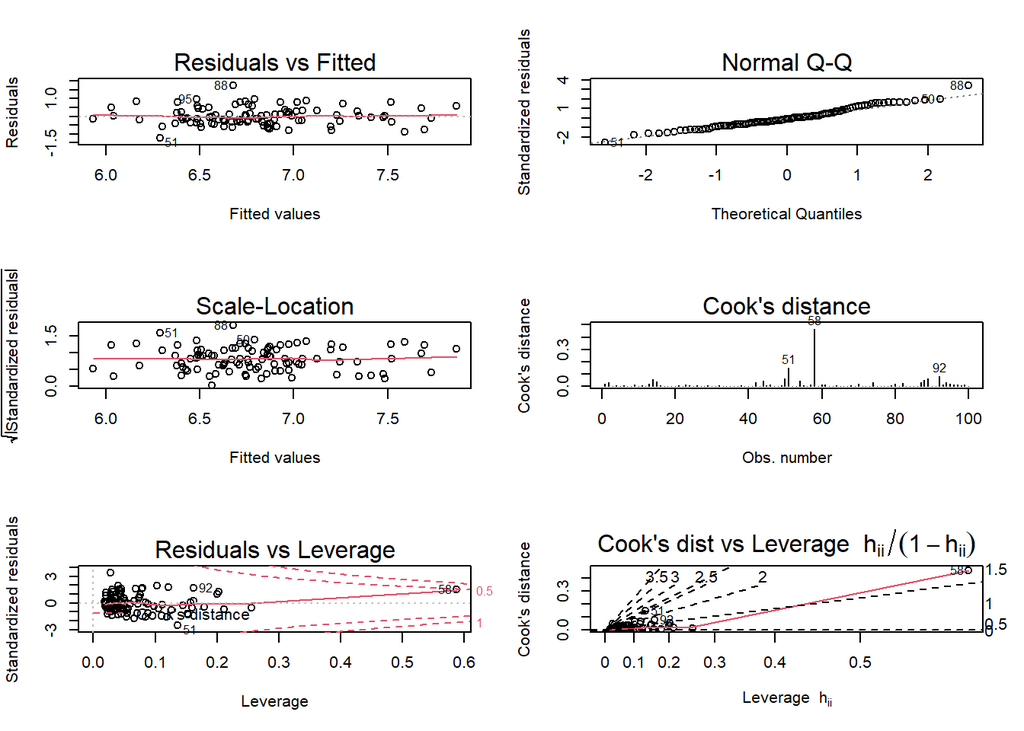

```r
par(mfrow=c(3,2))
plot(m1,1:6)
```

```r
Data[58,]
```

```
##        comp age educatn backgrd tenure exper    sales  val pcntown prof
## 58 6.533789  54       2       9     28    28 8.094684 1689   34.04  317
```

```r
dev.off()
```

```r
hist(resid(m1),freq=F, breaks=20)
points(-300:300/100,dnorm(-300:300/100,0,sd(resid(m1))),type="l",col="red")
```

[output not shown]

There is the clear outlier visible on all the plots before, owning 1/3 of his firm with the largest market value. This might be the only observation making `pcntown`. But actually, it is not like that:

```r
m0 <- lm(comp~.-backgrd-tenure-exper-val, data=Data[-58,])
summary(m0)
```

```
##
## Call:
## lm(formula = comp ~ . - backgrd - tenure - exper - val, data = Data[-58,
##     ])
##
## Residuals:
##      Min       1Q   Median       3Q      Max
## -1.16353 -0.32681 -0.07327  0.31351  1.77551
##
## Coefficients:
##               Estimate Std. Error t value Pr(>|t|)
## (Intercept)  5.0854738  0.7258814   7.006 3.97e-10 ***
## age          0.0094781  0.0087968   1.077 0.284096
## educatn1    -0.4567608  0.2337759  -1.954 0.053758 .
## educatn2    -0.6928302  0.2359073  -2.937 0.004189 **
## sales        0.2272492  0.0571379   3.977 0.000139 ***
## pcntown     -0.0453967  0.0182440  -2.488 0.014635 *
## prof         0.0003406  0.0001668   2.043 0.043954 *
## ---
## Signif. codes:  0 '***' 0.001 '**' 0.01 '*' 0.05 '.' 0.1 ' ' 1
##
## Residual standard error: 0.5183 on 92 degrees of freedom
## Multiple R-squared:  0.3822, Adjusted R-squared:  0.3419
## F-statistic: 9.485 on 6 and 92 DF,  p-value: 4.231e-08
```

```r
m0 <- lm(comp~.-backgrd-tenure-exper-val-age, data=Data)
anova(m0,m1)
```

```
## Analysis of Variance Table
##
## Model 1: comp ~ (age + educatn + backgrd + tenure + exper + sales + val +
##     pcntown + prof) - backgrd - tenure - exper - val - age
## Model 2: comp ~ (age + educatn + backgrd + tenure + exper + sales + val +
##     pcntown + prof) - backgrd - tenure - exper - val
##   Res.Df    RSS Df Sum of Sq      F Pr(>F)
## 1     94 25.701
## 2     93 25.333  1   0.36825 1.3519 0.2479
```

```r
m1 <- lm(comp~educatn+sales+pcntown+prof, data=Data)
summary(m1)
```

```
##
## Call:
## lm(formula = comp ~ educatn + sales + pcntown + prof, data = Data)
##
## Residuals:
##      Min       1Q   Median       3Q      Max
## -1.39011 -0.32346 -0.06428  0.32666  1.68113
##
## Coefficients:
##               Estimate Std. Error t value Pr(>|t|)
## (Intercept)  5.3977531  0.4885957  11.047  < 2e-16 ***
## educatn1    -0.4051182  0.2278766  -1.778  0.07867 .
## educatn2    -0.6166578  0.2177873  -2.831  0.00567 **
## sales        0.2447665  0.0568484   4.306 4.09e-05 ***
## pcntown     -0.0257820  0.0118891  -2.169  0.03264 *
## prof         0.0003778  0.0001671   2.261  0.02606 *
## ---
## Signif. codes:  0 '***' 0.001 '**' 0.01 '*' 0.05 '.' 0.1 ' ' 1
##
## Residual standard error: 0.5229 on 94 degrees of freedom
## Multiple R-squared:  0.3587, Adjusted R-squared:  0.3246
## F-statistic: 10.51 on 5 and 94 DF,  p-value: 4.903e-08
```

Since we are interested in the effect of education, let us take a look on interactions including education:

```r
m1 <- lm(comp~educatn*(sales+pcntown+prof), data=Data)
anova(m1)
```

```
## Analysis of Variance Table
##
## Response: comp
##                 Df  Sum Sq Mean Sq F value    Pr(>F)
## educatn          2  3.1787  1.5893  6.1288  0.003222 **
## sales            1  8.5188  8.5188 32.8504 1.373e-07 ***
## pcntown          1  1.2782  1.2782  4.9289  0.028980 *
## prof             1  1.3978  1.3978  5.3904  0.022558 *
## educatn:sales    2  0.0232  0.0116  0.0447  0.956284
## educatn:pcntown  2  1.6556  0.8278  3.1922  0.045880 *
## educatn:prof     2  1.2018  0.6009  2.3172  0.104537
## Residuals       88 22.8203  0.2593
## ---
## Signif. codes:  0 '***' 0.001 '**' 0.01 '*' 0.05 '.' 0.1 ' ' 1
```

```r
m0 <- lm(comp~sales+educatn*pcntown+prof, data=Data)
anova(m0,m1)
```

```
## Analysis of Variance Table
##
## Model 1: comp ~ sales + educatn * pcntown + prof
## Model 2: comp ~ educatn * (sales + pcntown + prof)
##   Res.Df    RSS Df Sum of Sq      F Pr(>F)
## 1     92 24.025
## 2     88 22.820  4    1.2045 1.1612 0.3335
```

```r
m1 <- m0
summary(m1)
```

```
##
## Call:
## lm(formula = comp ~ sales + educatn * pcntown + prof, data = Data)
##
## Residuals:
##      Min       1Q   Median       3Q      Max
## -1.11502 -0.34057 -0.07372  0.26350  1.66921
##
## Coefficients:
##                    Estimate Std. Error t value Pr(>|t|)
## (Intercept)       5.5263525  0.5171050  10.687  < 2e-16 ***
## sales             0.2462291  0.0555915   4.429  2.6e-05 ***
## educatn1         -0.4218455  0.3013236  -1.400  0.16488
## educatn2         -0.7727031  0.2866049  -2.696  0.00834 **
## pcntown          -0.0480467  0.0317488  -1.513  0.13362
## prof              0.0003105  0.0001661   1.870  0.06467 .
## educatn1:pcntown -0.0338107  0.0420946  -0.803  0.42392
## educatn2:pcntown  0.0411625  0.0346170   1.189  0.23747
## ---
## Signif. codes:  0 '***' 0.001 '**' 0.01 '*' 0.05 '.' 0.1 ' ' 1
##
## Residual standard error: 0.511 on 92 degrees of freedom
## Multiple R-squared:  0.4005, Adjusted R-squared:  0.3549
## F-statistic:  8.78 on 7 and 92 DF,  p-value: 3.13e-08
```

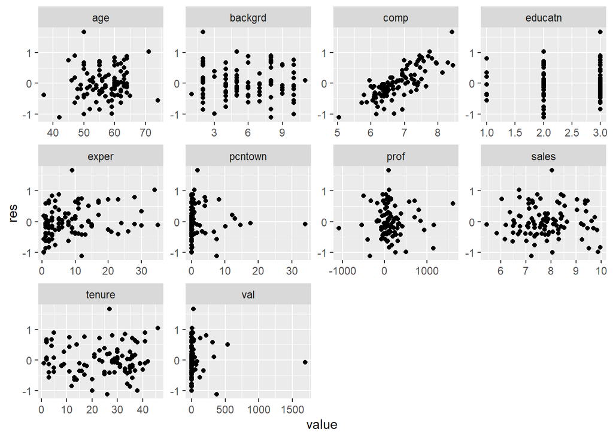

```r
resData <- Data
resData$res <- resid(m1)
resData %>% mutate(backgrd=as.numeric(backgrd), educatn=as.numeric(educatn)) %>% pivot_longer(colnames(resData)[colnames(resData) != "res"]) %>%
  ggplot(aes(y=res,x=value)) + facet_wrap(~ name, scales = "free") + geom_point()
```

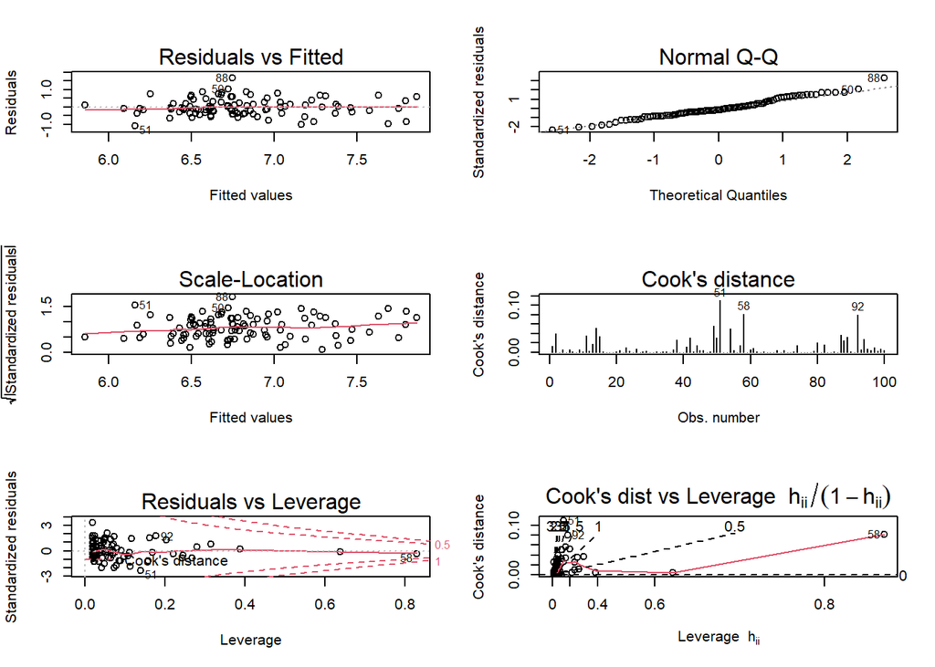

```r
par(mfrow=c(3,2))
plot(m1,1:6)
```

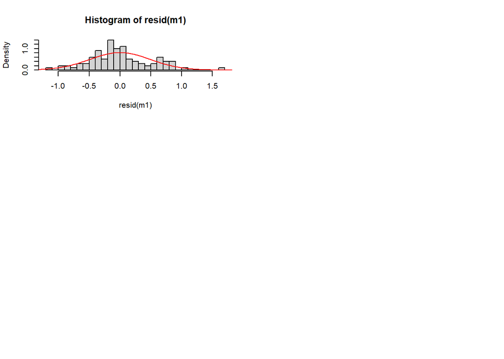

```r
hist(resid(m1),freq=F, breaks=20)
points(-300:300/100,dnorm(-300:300/100,0,sd(resid(m1))),type="l",col="red")
```

The only significant interaction is with ownership percentage, and it does seem to improve the residuals mildly.

## Interpretation

```r
Data <- read_data()
names(Data) <- tolower(names(Data))
Data <- Data %>% mutate(educatn=as.factor(educatn),comp=log(comp,2), sales=log(sales,2))
mfinal <- lm(comp~sales+educatn*pcntown+prof, data=Data)
summary(mfinal)
```

```
##
## Call:
## lm(formula = comp ~ sales + educatn * pcntown + prof, data = Data)
##
## Residuals:
##     Min      1Q  Median      3Q     Max
## -1.6086 -0.4913 -0.1064  0.3801  2.4082
##
## Coefficients:
##                    Estimate Std. Error t value Pr(>|t|)
## (Intercept)       7.9728413  0.7460248  10.687  < 2e-16 ***
## sales             0.2462291  0.0555915   4.429  2.6e-05 ***
## educatn1         -0.6085944  0.4347181  -1.400  0.16488
## educatn2         -1.1147750  0.4134834  -2.696  0.00834 **
## pcntown          -0.0693167  0.0458039  -1.513  0.13362
## prof              0.0004480  0.0002396   1.870  0.06467 .
## educatn1:pcntown -0.0487786  0.0607297  -0.803  0.42392
## educatn2:pcntown  0.0593850  0.0499418   1.189  0.23747
## ---
## Signif. codes:  0 '***' 0.001 '**' 0.01 '*' 0.05 '.' 0.1 ' ' 1
##
## Residual standard error: 0.7372 on 92 degrees of freedom
## Multiple R-squared:  0.4005, Adjusted R-squared:  0.3549
## F-statistic:  8.78 on 7 and 92 DF,  p-value: 3.13e-08
```

Given how small the no-college education group is, we could be interested rather in the difference between the undergrad and grad groups, which is given here

```r
Data <- read_data()
names(Data) <- tolower(names(Data))
Data <- Data %>% mutate(educatn=as.factor(-educatn),comp=log(comp,2), sales=log(sales,2))
mfinal <- lm(comp~sales+educatn*pcntown+prof, data=Data)
summary(mfinal)
```

```
##
## Call:
## lm(formula = comp ~ sales + educatn * pcntown + prof, data = Data)
##
## Residuals:
##     Min      1Q  Median      3Q     Max
## -1.6086 -0.4913 -0.1064  0.3801  2.4082
##
## Coefficients:
##                     Estimate Std. Error t value Pr(>|t|)
## (Intercept)        6.8580664  0.6193413  11.073  < 2e-16 ***
## sales              0.2462291  0.0555915   4.429  2.6e-05 ***
## educatn-1          0.5061805  0.1870772   2.706  0.00812 **
## educatn0           1.1147750  0.4134834   2.696  0.00834 **
## pcntown           -0.0099317  0.0202083  -0.491  0.62427
## prof               0.0004480  0.0002396   1.870  0.06467 .
## educatn-1:pcntown -0.1081635  0.0447765  -2.416  0.01768 *
## educatn0:pcntown  -0.0593850  0.0499418  -1.189  0.23747
## ---
## Signif. codes:  0 '***' 0.001 '**' 0.01 '*' 0.05 '.' 0.1 ' ' 1
##
## Residual standard error: 0.7372 on 92 degrees of freedom
## Multiple R-squared:  0.4005, Adjusted R-squared:  0.3549
## F-statistic:  8.78 on 7 and 92 DF,  p-value: 3.13e-08
```

## Further Checks

We have already done residual diagnostics. Given our goal (assessing the effect of education) and given the fact that we do not have multiple candidate models, let’s skip predictive checking and focus on sensitivity/stability. We haven’t really done anything questionable with our variables apart from 2 things:

- we have decided to include education as a factor (i.e. having 2 degrees of freedom), while it seems that including it as a numerical variable (i.e. with only a single degree of freedom) could have been enough
- we have taken a log of sales but not log of profits, even though those two variables are somewhat similar
  - also, we took the the log of sales to make the dependence more linear, but examining the residuals-against-sales plot closer (especially when we add `geom_smooth`) suggests we haven’t really made the dependence entirely linear

Apart from these two, it would be natural to consider

- a model with influential observations and outliers removed
- a simpler model `lm(comp~sales+educatn, data=Data)`

Is our surprising interpretation that higher level of education has a negative impact on CEO compensations sensitive to the choices above?

```r
Data <- read_data()
names(Data) <- tolower(names(Data))
Data <- Data %>% mutate(educatn=as.factor(educatn),comp=log(comp,2), sales=log(sales,2))
fit <- lm(comp~educatn+sales,data=Data)
summary(fit)
```

```
##
## Call:
## lm(formula = comp ~ educatn + sales, data = Data)
##
## Residuals:
##      Min       1Q   Median       3Q      Max
## -2.47683 -0.48831 -0.08914  0.43165  2.37784
##
## Coefficients:
##             Estimate Std. Error t value Pr(>|t|)
## (Intercept)  6.95556    0.67867  10.249  < 2e-16 ***
## educatn1    -0.31553    0.32950  -0.958   0.3407
## educatn2    -0.65117    0.31308  -2.080   0.0402 *
## sales        0.29887    0.05567   5.368 5.52e-07 ***
## ---
## Signif. codes:  0 '***' 0.001 '**' 0.01 '*' 0.05 '.' 0.1 ' ' 1
##
## Residual standard error: 0.7844 on 96 degrees of freedom
## Multiple R-squared:  0.2919, Adjusted R-squared:  0.2698
## F-statistic: 13.19 on 3 and 96 DF,  p-value: 2.781e-07
```

```r
which(hatvalues(m1)>0.5)
```

```
## 58 70
## 58 70
```

```r
fit <- lm(comp~sales+educatn*pcntown+prof, data=Data[-c(50,51,58,70,88),])
summary(fit)
```

```
##
## Call:
## lm(formula = comp ~ sales + educatn * pcntown + prof, data = Data[-c(50,
##     51, 58, 70, 88), ])
##
## Residuals:
##      Min       1Q   Median       3Q      Max
## -1.39065 -0.49531 -0.07975  0.41393  1.31812
##
## Coefficients:
##                    Estimate Std. Error t value Pr(>|t|)
## (Intercept)       7.8792848  0.7099144  11.099  < 2e-16 ***
## sales             0.2524514  0.0525878   4.801 6.52e-06 ***
## educatn1         -0.6255892  0.4218255  -1.483  0.14167
## educatn2         -1.1270139  0.4031258  -2.796  0.00637 **
## pcntown          -0.0615923  0.0638708  -0.964  0.33755
## prof              0.0003943  0.0002191   1.800  0.07537 .
## educatn1:pcntown -0.0243825  0.0741407  -0.329  0.74305
## educatn2:pcntown  0.0561450  0.0774085   0.725  0.47021
## ---
## Signif. codes:  0 '***' 0.001 '**' 0.01 '*' 0.05 '.' 0.1 ' ' 1
##
## Residual standard error: 0.6686 on 87 degrees of freedom
## Multiple R-squared:  0.4375, Adjusted R-squared:  0.3922
## F-statistic: 9.667 on 7 and 87 DF,  p-value: 7.617e-09
```

```r
Data <- read_data()
names(Data) <- tolower(names(Data))
Data <- Data %>% mutate(educatn=as.factor(educatn),comp=log(comp))
fit <- lm(comp~sales+I(sales^2)+educatn*pcntown+prof, data=Data)
summary(fit)
```

```
##
## Call:
## lm(formula = comp ~ sales + I(sales^2) + educatn * pcntown +
##     prof, data = Data)
##
## Residuals:
##      Min       1Q   Median       3Q      Max
## -1.01871 -0.33381 -0.05192  0.24228  1.63569
##
## Coefficients:
##                    Estimate Std. Error t value Pr(>|t|)
## (Intercept)       6.943e+00  2.837e-01  24.469  < 2e-16 ***
## sales             1.991e-04  3.804e-05   5.233 1.06e-06 ***
## I(sales^2)       -9.391e-09  2.068e-09  -4.542 1.71e-05 ***
## educatn1         -4.087e-01  2.901e-01  -1.409   0.1623
## educatn2         -7.006e-01  2.767e-01  -2.532   0.0131 *
## pcntown          -4.189e-02  3.066e-02  -1.366   0.1752
## prof              3.457e-04  1.628e-04   2.124   0.0364 *
## educatn1:pcntown -3.863e-02  4.055e-02  -0.953   0.3432
## educatn2:pcntown  3.268e-02  3.339e-02   0.979   0.3303
## ---
## Signif. codes:  0 '***' 0.001 '**' 0.01 '*' 0.05 '.' 0.1 ' ' 1
##
## Residual standard error: 0.4919 on 91 degrees of freedom
## Multiple R-squared:  0.4506, Adjusted R-squared:  0.4023
## F-statistic:  9.33 on 8 and 91 DF,  p-value: 2.58e-09
```

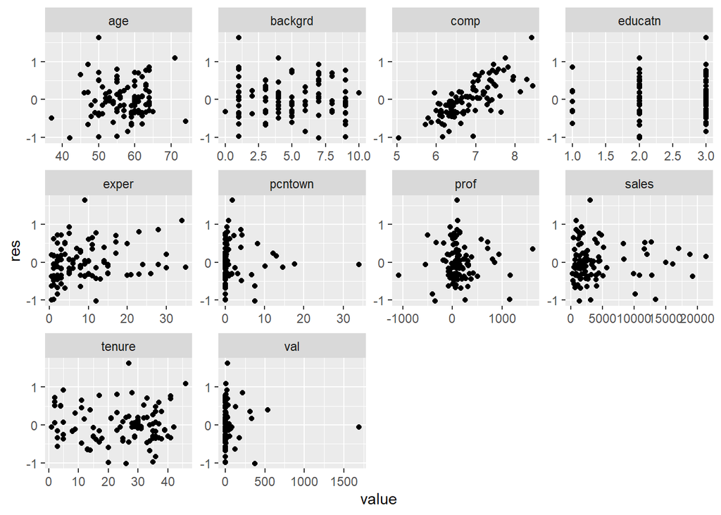

```r
resData <- Data %>% select(-company,-birth)
resData$res <- resid(fit)
resData %>% mutate(backgrd=as.numeric(backgrd), educatn=as.numeric(educatn)) %>% pivot_longer(colnames(resData)[colnames(resData) != "res"]) %>%
  ggplot(aes(y=res,x=value)) + facet_wrap(~ name, scales = "free") + geom_point()
```

The negative effect of education is not sensitive with respect to our model choice.

Just for fun, let’s say we want to see whether our final model improves prediction over the simpler model. We will cross-validate MSE, and do it in a separate script so we don’t have to wait for the CV to run whenever we knit this Rmarkdown file.

```r
load("cv_data.RData")
rowMeans(ERR)
```

```
## [1] 5.828098 6.390339
```

We can see that our final model is better.

It seems there is no problem with multicollinearity from the point of the variance inflation factor, but the condition number is really large, though this is also the case for simpler models and it is caused by the fact that there are very few observations in the no-degree class of the education variable, which are all very similar w.r.t. sales:

```r
library(car)
vif(mfinal)
```

```
##                     GVIF Df GVIF^(1/(2*Df))
## sales           1.170456  1        1.081876
## educatn         2.734185  2        1.285899
## pcntown         1.595899  1        1.263289
## prof            1.226383  1        1.107422
## educatn:pcntown 3.664588  2        1.383586
```

```r
kappa(vcov(mfinal))
```

```
## [1] 6552284
```

```r
msimpler <- lm(comp~sales+educatn, data=Data)
kappa(vcov(msimpler))
```

```
## [1] 1196861605
```

We cannot really do anything about this, it is just important to be aware of our model’s limitations.